# Introduction SQL in RStudio, part 3

Antoinette Littel

November 2019

## Connecting to the database

The first chunk in this Notebook will run automatically when you make the SQL statements. It loads the libraries you need and connects to the database ‘WPC.db’ that should be in your folder.

## database design

Below is the design of the database. You should have this picture in the images folder of your workdirectory. You can open the picture next to your Notebook, so that you can see the design while creating your queries.

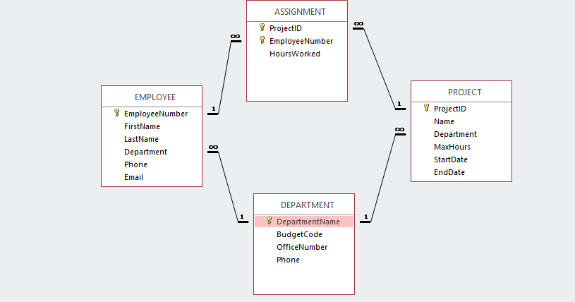

## Assignments

Make a SQL query for the following questions. The desired result is printed below each question. Use ggplot visualization where asked.

G. Which employees work for the Administration, Accounting, Production and Legal departments? Show the employee number, first name, last name and department name. Order the results in alphabetical order of the department name and then in alphabetical order of the employee’s last name

| EmployeeNumber | FirstName | LastName | Department |
| --- | --- | --- | --- |
| 4 | Tom | Caruthers | Accounting |
| 5 | Heather | Jones | Accounting |
| 2 | Rosalie | Jackson | Administration |
| 1 | Mary | Jacobs | Administration |
| 8 | Tom | Jackson | Production |
| 9 | George | Jones | Production |

H. How many projects are being run by the marketing department? Be sure to assign an appropriate column name to the computed results.

| NumberOfProjectMarketingRuns |
| --- |
| 2 |

I. What is the total MaxHours of projects being run by the marketing department? Be sure to assign an appropriate column name to the computed results

| TotalMaxHours |
| --- |
| 285 |

J. What is the average MaxHours of projects being run by the marketing department? Be sure to assign an appropriate column name to the computed results.

| AVGMaxHours |
| --- |
| 142.5 |

K. How many projects are being run by each department? Be sure to display each DepartmentName and to assign an appropriate column name to the computed results.

| Department | NumberOfProjects |
| --- | --- |
| Accounting | 1 |
| Finance | 2 |
| Marketing | 2 |

L. Which employees have been assigned to at least 2 projects in which he or she has worked at least 20 hours? List the employee number and the number of those projects.

| EmployeeNumber | NumberofProjectsMoreThan20hours |
| --- | --- |
| 1 | 3 |
| 4 | 2 |
| 6 | 2 |
| 8 | 2 |
| 10 | 2 |

M. Which projects are run by a department which uses the budgetcode ‘BC-700-10’. Use a subquery.

| ProjectID | Name | Department | MaxHours | StartDate | EndDate |
| --- | --- | --- | --- | --- | --- |
| 1000 | 2008 Q3 Product Plan | Marketing | 135 | 2008-10-05 | 2008-06-15 |
| 1300 | 2008 Q4 Product Plan | Marketing | 150 | 2008-08-10 | 2008-09-15 |

N. Which projects are run by a department with phone number 360-285-8400. Use a subquery.

| ProjectID | Name | Department | MaxHours | StartDate | EndDate |
| --- | --- | --- | --- | --- | --- |
| 1100 | 2008 Q3 Porfolio Analysis | Finance | 120 | 2008-07-01 | 2008-07-25 |
| 1400 | 2008 Q4 Portfolio Analysis | Finance | 140 | 2008-10-05 | NA |

O. What is the minimum and the maximum amount of hours worked by an employee, for each project? List the projectID, the minimum amount of hours worked and the maximum amount of hours worked

| ProjectID | MinimumHoursWorked | MaximumHoursWorked |
| --- | --- | --- |
| 1000 | 30 | 75.0 |
| 1100 | 25 | 45.0 |
| 1200 | 20 | 45.0 |
| 1300 | 35 | 80.0 |
| 1400 | 10 | 27.5 |

P. Which employees are working for office number BLDG01-300? List the employee number, first name and last name. Use a sub-query to solve this exercise.

| EmployeeNumber | FirstName | LastName |
| --- | --- | --- |
| 1 | Mary | Jacobs |
| 2 | Rosalie | Jackson |

Q. Who are the employees assigned to each project? Show ProjectID, Employee-Number, LastName, FirstName, and Phone.

| ProjectID | EmployeeNumber | LastName | FirstName | Phone |
| --- | --- | --- | --- | --- |
| 1300 | 1 | Jacobs | Mary | 360-285-8110 |
| 1100 | 1 | Jacobs | Mary | 360-285-8110 |
| 1000 | 1 | Jacobs | Mary | 360-285-8110 |
| 1200 | 2 | Jackson | Rosalie | 360-285-8120 |
| 1400 | 4 | Caruthers | Tom | 360-285-8310 |
| 1200 | 4 | Caruthers | Tom | 360-285-8310 |
| 1100 | 4 | Caruthers | Tom | 360-285-8310 |
| 1400 | 5 | Jones | Heather | 360-285-8320 |
| 1200 | 5 | Jones | Heather | 360-285-8320 |
| 1400 | 6 | Abernathy | Mary | 360-285-8410 |

[output cut: 5 more lines]

R. Who are the employees assigned to each project? Show the ProjectID, Name, and Department. Show EmployeeNumber, LastName, FirstName, and Phone.

| ProjectID | Name | Department | EmployeeNumber | LastName | FirstName | Phone |
| --- | --- | --- | --- | --- | --- | --- |
| 1000 | 2008 Q3 Product Plan | Marketing | 1 | Jacobs | Mary | 360-285-8110 |
| 1000 | 2008 Q3 Product Plan | Marketing | 8 | Jackson | Tom | 360-287-8610 |
| 1000 | 2008 Q3 Product Plan | Marketing | 10 | Numoto | Ken | 360-287-8710 |
| 1100 | 2008 Q3 Porfolio Analysis | Finance | 1 | Jacobs | Mary | 360-285-8110 |
| 1100 | 2008 Q3 Porfolio Analysis | Finance | 4 | Caruthers | Tom | 360-285-8310 |
| 1100 | 2008 Q3 Porfolio Analysis | Finance | 6 | Abernathy | Mary | 360-285-8410 |
| 1200 | 2008 Q3 Task Preparation | Accounting | 2 | Jackson | Rosalie | 360-285-8120 |
| 1200 | 2008 Q3 Task Preparation | Accounting | 4 | Caruthers | Tom | 360-285-8310 |
| 1200 | 2008 Q3 Task Preparation | Accounting | 5 | Jones | Heather | 360-285-8320 |
| 1300 | 2008 Q4 Product Plan | Marketing | 1 | Jacobs | Mary | 360-285-8110 |

[output cut: 5 more lines]

S. Who are the employees assigned to each project? Show ProjectID, Name, Department, and Department Phone. Show EmployeeNumber, LastName, FirstName, and Employee Phone. Sort by ProjectID in ascending order.

| ProjectID | Name | Department | Phone | EmployeeNumber | LastName | FirstName | Phone..8 |
| --- | --- | --- | --- | --- | --- | --- | --- |
| 1000 | 2008 Q3 Product Plan | Marketing | 360-287-8700 | 1 | Jacobs | Mary | 360-285-8110 |
| 1000 | 2008 Q3 Product Plan | Marketing | 360-287-8700 | 8 | Jackson | Tom | 360-287-8610 |
| 1000 | 2008 Q3 Product Plan | Marketing | 360-287-8700 | 10 | Numoto | Ken | 360-287-8710 |
| 1100 | 2008 Q3 Porfolio Analysis | Finance | 360-285-8400 | 1 | Jacobs | Mary | 360-285-8110 |
| 1100 | 2008 Q3 Porfolio Analysis | Finance | 360-285-8400 | 4 | Caruthers | Tom | 360-285-8310 |
| 1100 | 2008 Q3 Porfolio Analysis | Finance | 360-285-8400 | 6 | Abernathy | Mary | 360-285-8410 |
| 1200 | 2008 Q3 Task Preparation | Accounting | 360-285-8300 | 2 | Jackson | Rosalie | 360-285-8120 |
| 1200 | 2008 Q3 Task Preparation | Accounting | 360-285-8300 | 4 | Caruthers | Tom | 360-285-8310 |
| 1200 | 2008 Q3 Task Preparation | Accounting | 360-285-8300 | 5 | Jones | Heather | 360-285-8320 |
| 1300 | 2008 Q4 Product Plan | Marketing | 360-287-8700 | 1 | Jacobs | Mary | 360-285-8110 |

[output cut: 5 more lines]

T. Who are the employees assigned to projects run by the marketing department? Show ProjectID, Name, Departmentname (of the employee), and Department Phone. Show EmployeeNumber, LastName, FirstName, and Employee Phone. Sort by ProjectID in ascending order.

| ProjectID | Name | Department | Phone | EmployeeNumber | LastName | FirstName | Phone..8 |
| --- | --- | --- | --- | --- | --- | --- | --- |
| 1000 | 2008 Q3 Product Plan | Marketing | 360-287-8700 | 1 | Jacobs | Mary | 360-285-8110 |
| 1000 | 2008 Q3 Product Plan | Marketing | 360-287-8700 | 8 | Jackson | Tom | 360-287-8610 |
| 1000 | 2008 Q3 Product Plan | Marketing | 360-287-8700 | 10 | Numoto | Ken | 360-287-8710 |
| 1300 | 2008 Q4 Product Plan | Marketing | 360-287-8700 | 1 | Jacobs | Mary | 360-285-8110 |
| 1300 | 2008 Q4 Product Plan | Marketing | 360-287-8700 | 8 | Jackson | Tom | 360-287-8610 |
| 1300 | 2008 Q4 Product Plan | Marketing | 360-287-8700 | 10 | Numoto | Ken | 360-287-8710 |

U. Which employees have been assigned to a project? Show the employee number, first name and last name. Make 2 different queries to solve this problem!

| EmployeeNumber | FirstName | LastName |
| --- | --- | --- |
| 1 | Mary | Jacobs |
| 2 | Rosalie | Jackson |
| 4 | Tom | Caruthers |
| 5 | Heather | Jones |
| 6 | Mary | Abernathy |
| 8 | Tom | Jackson |
| 10 | Ken | Numoto |

| EmployeeNumber | FirstName | LastName |
| --- | --- | --- |
| 1 | Mary | Jacobs |
| 2 | Rosalie | Jackson |
| 4 | Tom | Caruthers |
| 5 | Heather | Jones |
| 6 | Mary | Abernathy |
| 8 | Tom | Jackson |
| 10 | Ken | Numoto |

V. List the employees that have worked in total more than 100 hours for marketing projects. List the employee number, last name, first name and the total amount of hours worked for marketing projects

| EmployeeNumber | FirstName | LastName | TotalHoursWorkedForMarketingProjects |
| --- | --- | --- | --- |
| 8 | Tom | Jackson | 155 |
| 10 | Ken | Numoto | 105 |

## Extra assignments to practice more

Per topic are extra assignments.

### subqueries

E1. List the emailadresses of employees working in the department with phone ‘360-285-8400’

| Email |
| --- |
| Mabernathy@WPC.com |

E2. List the StartDate of projects that were assigned to employees with the firstname ‘Tom’.

| StartDate |
| --- |
| 2008-10-05 |
| 2008-07-01 |
| 2008-08-10 |
| 2008-08-10 |
| 2008-10-05 |

### GROUP BY

E3. Count the number of projects per department.

| Department | NumberOfProjects |
| --- | --- |
| Accounting | 1 |
| Finance | 2 |
| Marketing | 2 |

E4. Count the number of employees per project.

| ProjectID | NumberOfEmployees |
| --- | --- |
| 1000 | 3 |
| 1100 | 3 |
| 1200 | 3 |
| 1300 | 3 |
| 1400 | 3 |

E5. Give the total hours worked per project.

| ProjectID | Totalhoursworked |
| --- | --- |
| 1000 | 160.0 |
| 1100 | 110.0 |
| 1200 | 105.0 |
| 1300 | 165.0 |
| 1400 | 52.5 |

## Challenging assignments

C1. Now use the query results of assignment R to visualize the number of project per department with `ggplot`. Make two chunks: a sql chunk and a R chunk.

Remember to use the `{r}` tag in your chunk to switch to regular R again.

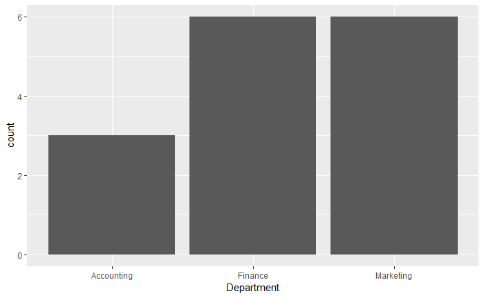

[figure not shown]